# TP Optimisation

## Binôme : **Tom Dupuis** - **Clément Bonnet**

## 1. Optimisation continue sous contrainte

## 1.1.1 Résolution du problème primal

```python
from functools import partial
from IPython.display import Markdown as md, display
import matplotlib.pyplot as plt
import numpy as np
from scipy.optimize import minimize
from scipy.spatial.distance import cdist
import time
```

```python
def objective(x):
    """
    Returns the objective function sum(exp(x_i) + ix_i/N)
    """
    N = len(x)
    return sum(np.exp(x)) + 1/N * sum((np.arange(N)+1)*x)

def constraint(x):
    """
    sum(x_i) >= 1
    """
    return sum(x) - 1
```

```python
constraint = {"type": "ineq", "fun": constraint}
```

```python
def optim_primal(N):
    x0 = np.ones(N)
    t0 = time.perf_counter()
    sol = minimize(objective, x0, constraints=constraint)
    t1 = time.perf_counter()
    return sol, t1-t0

def print_sol_primal(N):
    sol, t = optim_primal(N)
    fun, x = sol["fun"], sol["x"]
    plt.scatter(np.arange(len(x))+1, x)
    return md("""#### Résultats pour N={}
        Valeur optimale de la fonction : {:.3f}
        Temps d'exécution : {:.2f} {}
##### Tracé de x optimal""".format(N, fun, 1000*t if t<1 else t, "ms" if t<1 else "s"))
```

Résultats pour N=10

```
    Valeur optimale de la fonction : 11.227
    Temps d'exécution : 4.44 ms
```

Tracé de x optimal

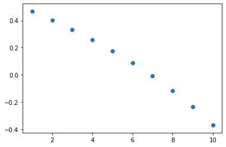

```python
print_sol_primal(10)
```

Résultats pour N=100

```
    Valeur optimale de la fonction : 97.368
    Temps d'exécution : 58.48 ms
```

Tracé de x optimal

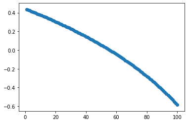

```python
print_sol_primal(100)
```

Résultats pour N=1000

```
    Valeur optimale de la fonction : 959.698
    Temps d'exécution : 8.51 s
```

Tracé de x optimal

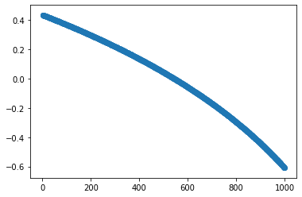

```python
print_sol_primal(1000)
```

## 1.1.2 Résolution du problème dual

### a) Fonction de Lagrange et fonction duale

$$ L(x, \lambda) = \sum_{i=1}^N e^{x_i} + \sum_{i=1}^N (\frac{i}{N} - \lambda)x_i + \lambda $$

$$ \underline{L}(\lambda) = \inf_{x \in \mathbb{R}^N} L(x, \lambda) $$

Pour $\lambda \in \mathbb{R}^+$, trouvons le minimum sur $\mathbb{R}^N$ de $x \mapsto L(x, \lambda)$.  
Si $\lambda \ge 1$, la fonction $x \mapsto L(x, \lambda)$ est convexe

$$ \frac{\partial L}{\partial x_i}(x, \lambda) = e^{x_i} + \frac{i}{N} - \lambda $$

$$ \begin{align} \frac{\partial L}{\partial x_i}(\underline{x}, \lambda) = 0 &\iff e^{\underline{x_i}} + \frac{i}{N} - \lambda = 0 \\ &\iff \underline{x_i} = \ln(\lambda - \frac{i}{N}) \\ \end{align} $$

En remplaçant dans l'expression de $\underline{L}(\lambda)$,

$$ \begin{align} \underline{L}(\lambda) &= \sum_{i=1}^N (\lambda - \frac{i}{N}) - \sum_{i=1}^N (\lambda - \frac{i}{N})\ln(\lambda - \frac{i}{N}) + \lambda \\ \underline{L}(\lambda) &= \sum_{i=1}^N \big(\lambda - \frac{i}{N}\big)\big(1 - \ln(\lambda - \frac{i}{N})\big) + \lambda \end{align} $$

Si $\lambda \lt 1$, pour $x_N = -t$, $t \gt 0$ et $x_i = 0$ pour $i \neq N$,

$$ \begin{align} L(x, \lambda) &= N - 1 + e^{-t} - (1-\lambda)t + \lambda \\ \lim_{t \rightarrow +\infty} L(x, \lambda) &= -\infty \end{align} $$

Par conséquent, $\underline{L}(\lambda) = -\infty$

En conclusion,

$$ \boxed{\underline{L}(\lambda) = \begin{cases} \sum_{i=1}^N \big(\lambda - \frac{i}{N}\big)\big(1 - \ln(\lambda - \frac{i}{N})\big) + \lambda &\text{if } \lambda \gt 1 \\ - \infty &\text{if } \lambda \le 1 \\ \end{cases}} $$

### b) Expression du problème dual

$$ \begin{align} &\max_{\lambda \in \mathbb{R}} \underline{L}(\lambda) \\ &\lambda \ge 0 \\ \end{align} $$

En remplaçant par la formule de $\underline{L}(\lambda)$,

$$ \boxed{\begin{align} &\max_{\lambda \in \mathbb{R}} \sum_{i=1}^N \big(\lambda - \frac{i}{N}\big)\big(1 - \ln(\lambda - \frac{i}{N})\big) + \lambda \\ &\lambda \gt 1 \\ \end{align}} $$

### c) Optimisation de la fonction duale

```python
def dual(N, l):
    return - (sum((l - 1/N * (1+np.arange(N)))*(1 - np.log(l -  1/N * (1+np.arange(N))))) + l)
```

```python
eps = 10**-7
bounds = [(1+eps,None)]
```

```python
def optim_dual(N):
    l = 2
    t0 = time.perf_counter()
    sol = minimize(partial(dual, N), l, bounds=bounds)
    t1 = time.perf_counter()
    return sol, t1-t0

def print_sol_dual(N):
    sol, t = optim_dual(N)
    fun = -sol["fun"][0]
    return md("""#### Résultats pour N={}
        Valeur optimale de la fonction : {:.3f}
        Temps d'exécution : {:.2f} {}
        """.format(N, fun, 1000*t if t<1 else t, "ms" if t<1 else "s"))
```

$$ \min_{x \in \mathbb{R}^N} f(x) = \max_{\lambda \in \mathbb{R}} g(\lambda) $$

```python
print_sol_dual(10)
```

Résultats pour N=10

```
    Valeur optimale de la fonction : 11.227
    Temps d'exécution : 58.32 ms
```

```python
print_sol_dual(100)
```

Résultats pour N=100

```
    Valeur optimale de la fonction : 97.368
    Temps d'exécution : 1.44 ms
```

```python
print_sol_dual(1000)
```

Résultats pour N=1000

```
    Valeur optimale de la fonction : 959.698
    Temps d'exécution : 3.70 ms
```

### d) Comparaison primal / dual

On retrouve bien les mêmes valeurs optimales de fonctions pour $\min_{x \in \mathbb{R}^N} f(x)$ et $\max_{\lambda \in \mathbb{R}} g(\lambda)$

```python
prim10 = optim_primal(10)[0]["fun"]
prim100 = optim_primal(100)[0]["fun"]
prim1000 = optim_primal(1000)[0]["fun"]
dual10 = -optim_dual(10)[0]["fun"][0]
dual100 = -optim_dual(100)[0]["fun"][0]
dual1000 = -optim_dual(1000)[0]["fun"][0]
```

```python
display(md(f"""
$N = 10 \implies \min f(x) = {round(prim10, 1)}$ and $\max g(\lambda) = {round(dual10, 1)}$ \\
$N = 100 \implies \min f(x) = {round(prim100, 1)}$ and $\max g(\lambda) = {round(dual100, 1)}$ \\
$N = 1000 \implies \min f(x) = {round(prim1000, 1)}$ and $\max g(\lambda) = {round(dual1000, 1)}$
"""))
```

$N = 10 \implies \min f(x) = 11.2$ and $\max g(\lambda) = 11.2$ \ $N = 100 \implies \min f(x) = 97.4$ and $\max g(\lambda) = 97.4$ \ $N = 1000 \implies \min f(x) = 959.7$ and $\max g(\lambda) = 959.7$

Résoudre le primal et le dual amènent bien aux mêmes solutions.

## 2. Optimisation discrète

## 2.1 Rangement d'objets

#### Disclaimer:

Pour un soucis de clarté et de cohérence avec les indices de Python, les objets et boîtes seront annotées de 0 à N-1 et non de 1 à N !

Si cela pose une différence avec l'énoncé d'une question, la question sera reformulée en texte dans le TP avec les indices Python, afin de ne pas perdre le lecteur.

```python
from itertools import product
from sys import stdout as out
from mip import Model, xsum, minimize, maximize, BINARY, INTEGER
import seaborn as sns
import matplotlib.pyplot as plt
from scipy.sparse.csgraph import minimum_spanning_tree
from scipy.sparse import csr_matrix
```

```python
objets = np.array([[0.864397, -0.614946], [0.094203, -0.254635], [-0.851909, -0.26983],[0.873504, -1.671994],[-0.438039, -1.876045],[-0.429661, 0.575006],[-1.102729, -0.866133],[0.396247, -2.116523],[-0.964925, -0.964466],[0.168449, 0.212729],[-1.965359, 0.477917],[-0.744302, 0.100658],[-0.552307, 0.297433],[-0.552307, -0.297433],[1.109142, -1.624496]])
boites = np.array([[-0.5, 0],[-0.428571428571429, 0],[-0.357142857142857, 0],[-0.285714285714286, 0],[-0.214285714285714, 0],[-0.142857142857143, 0],[-0.0714285714285715, 0],[0, 0],[0.0714285714285714, 0],[0.142857142857143, 0],[0.214285714285714, 0],[0.285714285714286, 0],[0.357142857142857, 0],[0.428571428571429, 0],[0.5, 0]])
```

Le problème s'apparente en fait à un problème du voyageur du commerce, avec une contrainte en moins. En effet, si l'on écrit $[d_{i,j}]_{i,j \in I,J}$ avec $I = [\![0, n-1]\!]$ la matrice des distances entre les boites i et les objets j, le problème s'écrit de la façon suivante:

$min \sum_{i \in I, j\in I}^{}d_{ij} x_{ij} \\ s.t: \\ \sum_{i \in I}^{}x_{ij}=1 \ \ \ \forall j \in I \\ \sum_{j \in I}^{}x_{ij}=1 \ \ \ \forall i \in I \\ x_{i,j} \in \{0,1\} \\I = [\![0,n-1]\!]$

$ x_{i,j}$ est la variable prenant comme valeur 1 si l'objet j est rangé dans la boîte i et 0 sinon.

Nous allons utiliser le package MIP de python pour résoudre ce problème d'optimisation linéaire en nombre entiers.

```
Répartition trouvée avec distance totale: 15.377627809988198
```

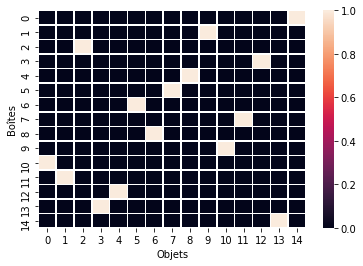

```
OptimizationStatus.OPTIMAL
```

```python
n, I = len(objets), set(range(len(objets)))

# matrice des distances
d = cdist(boites, objets)

model = Model()

# variable binaire indicant si l'objet j est dans la boite i
x = [[model.add_var(var_type=BINARY) for j in I] for i in I]

# ajout de l'objectif: minimiser la distance totale
model.objective = minimize(xsum(d[i][j]*x[i][j] for i in I for j in I))

# contrainte: chaque boîte contient exactement un seul objet
for i in I:
    model += xsum(x[i][j] for j in I) == 1

# contrainte: chaque objet est dans une boîte et une seule
for j in I:
    model += xsum(x[i][j] for i in I) == 1

# optimisation
status = model.optimize()

# on vérifie si une solution à été trouvée, et on l'affiche le cas échéant
if model.num_solutions > 0:
    out.write('Répartition trouvée avec distance totale: %s'
              % (model.objective_value))
    X = [[x[j][i].x for j in I] for i in I]
    sns.heatmap(X, linewidths=.5)
    plt.xlabel('Objets')
    plt.ylabel('Boîtes')
    plt.show()
print(status)
```

Rajoutons la contrainte suivante: l'objet 1 (indice 0) doit se situer dans la boîte située jsute à gauche de la boîte contenant l'objet 2 (indice 1).

Cette contrainte se formule mathématiquement:

$\\ \forall i \in I \backslash \{n-1\} \ \ \ \ x_{i+1,1} - x_{i,0} = 0$

```
Répartition trouvée avec distance totale: 15.565123298125489
```

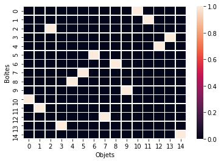

```
OptimizationStatus.OPTIMAL
```

```python
n, I = len(objets), set(range(len(objets)))

# matrice des distances
d = cdist(boites, objets)

model = Model()

# variable binaire indicant si l'objet j est dans la boite i
x = [[model.add_var(var_type=BINARY) for j in I] for i in I]

# ajout de l'objectif: minimiser la distance totale
model.objective = minimize(xsum(d[i][j]*x[i][j] for i in I for j in I))

# contrainte: chaque boîte contient exactement un seul objet
for i in I:
    model += xsum(x[i][j] for j in I) == 1

# contrainte: chaque objet est dans une boîte et une seule
for j in I:
    model += xsum(x[i][j] for i in I) == 1

#contrainte: l'objet 1 doit se trouver dans la boîte juste à gauche de la boîte contenant l'objet 2
for i in I - {n-1}:
    model += x[i+1][1] - x[i][0] == 0

# optimisation
status = model.optimize()

# on vérifie si une solution à été trouvée, et on l'affiche le cas échéant
if model.num_solutions >0:
    out.write('Répartition trouvée avec distance totale: %s'
              % (model.objective_value))
    X = [[x[i][j].x for j in I] for i in I]
    sns.heatmap(X, linewidths=.5)
    plt.xlabel('Objets')
    plt.ylabel('Boîtes')
    plt.show()
print(status)
```

Rajoutons la contrainte suivante:

$x_{i,2} + \sum_{k>0}x_{i+k,3} \leq 1 \ \ \forall i$

Cela signifie que l'objet 4 (indice 3) doit se situer à gauche de l'objet 3 (indice 2) dans les boîtes.

```
Répartition trouvée avec distance totale: 15.901379430360377
```

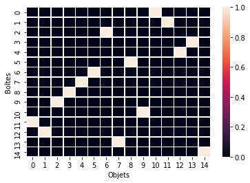

```
OptimizationStatus.OPTIMAL
```

```python
n, I = len(objets), set(range(len(objets)))

# matrice des distances
d = cdist(boites, objets)

model = Model()

# variable binaire indicant si l'objet j est dans la boite i
x = [[model.add_var(var_type=BINARY) for j in I] for i in I]

# ajout de l'objectif: minimiser la distance totale
model.objective = minimize(xsum(d[i][j]*x[i][j] for i in I for j in I))

# contrainte: chaque boîte contient exactement un seul objet
for i in I:
    model += xsum(x[i][j] for j in I) == 1

# contrainte: chaque objet est dans une boîte et une seule
for j in I:
    model += xsum(x[i][j] for i in I) == 1

#contrainte: l'objet 1 doit se trouver dans la boîte juste à gauche de la boîte contenant l'objet 2
for i in I - {n-1}:
    model += x[i+1][1] - x[i][0] == 0

#contrainte: l'objet 4 doit se situer à gauche de l'objet 3 dans les boîtes
for i in I - {n-1}:
    model += x[i][2] + xsum(x[i+k][3] for k in range(1, n-i)) <= 1

# optimisation
status = model.optimize()

# on vérifie si une solution à été trouvée, et on l'affiche le cas échéant
if model.num_solutions >0:
    out.write('Répartition trouvée avec distance totale: %s'
              % (model.objective_value))
    X = [[x[i][j].x for j in I] for i in I]
    sns.heatmap(X, linewidths=.5)
    plt.xlabel('Objets')
    plt.ylabel('Boîtes')
    plt.show()
print(status)
```

On vérifie bien que l'objet 4 se situe à gauche de l'objet 3 dans les boites (indices 3 et 2 !)

On rajoute maintenant la contrainte suivante:

La boîte contenant l'objet 7 (indice 6) se situe à côté de la boîte contenant l'objet 9 (indice 8). Cela se traduit mathématiquement:

$ x_{i,6} + \sum_{j \in I} (x_{j,8}) - x_{i-1,8} - x_{i+1,8} \leq 1 \ \ \ \forall i \in I \backslash \{0, n-1\} \\ x_{0,6} + \sum_{j \in I} (x_{j,8}) - x_{1,8} \leq 1 \\ x_{n-1,6} + \sum_{j \in I} (x_{j,8}) - x_{n-2,8}\leq 1 $

```
Répartition trouvée avec distance totale: 15.904808342529503
```

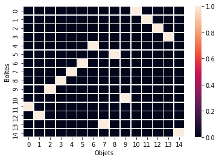

```
OptimizationStatus.OPTIMAL
```

```python
n, I = len(objets), set(range(len(objets)))

# matrice des distances
d = cdist(boites, objets)

model = Model()

# variable binaire indicant si l'objet j est dans la boite i
x = [[model.add_var(var_type=BINARY) for j in I] for i in I]

# ajout de l'objectif: minimiser la distance totale
model.objective = minimize(xsum(d[i][j]*x[i][j] for i in I for j in I))

# contrainte: chaque boîte contient exactement un seul objet
for i in I:
    model += xsum(x[i][j] for j in I) == 1

# contrainte: chaque objet est dans une boîte et une seule
for j in I:
    model += xsum(x[i][j] for i in I) == 1

#contrainte: l'objet 1 doit se trouver dans la boîte juste à gauche de la boîte contenant l'objet 2
for i in I - {n-1}:
    model += x[i+1][1] - x[i][0] == 0

#contrainte: l'objet 4 doit se situer à gauche de l'objet 3 dans les boîtes
for i in I - {n-1}:
    model += x[i][2] + xsum(x[i+k][3] for k in range(1, n-i)) <= 1

#contrainte : l'objet 7 est à côté de l'objet 9 dans les boîtes
for i in range(1,n-1):
    model += x[i][6] + xsum(x[j][8] for j in I) - x[i-1][8] - x[i+1][8] <= 1
model += x[0][6] + xsum(x[j][8] for j in I) - x[1][8] <= 1
model += x[n-1][6] + xsum(x[j][8] for j in I) - x[n-2][8] <= 1

# optimisation
status = model.optimize()

# on vérifie si une solution à été trouvée, et on l'affiche le cas échéant
if model.num_solutions >0:
    out.write('Répartition trouvée avec distance totale: %s'
              % (model.objective_value))
    X = [[x[i][j].x for j in I] for i in I]
    sns.heatmap(X, linewidths=.5)
    plt.xlabel('Objets')
    plt.ylabel('Boîtes')
    plt.show()
print(status)
```

Encore une fois, la condition supplémentaire est bien vérifiée, les objets 7 et 9 (indices 6 et 8) sur le graphe sont côté à côte.

```python
model.num_solutions
```

```
1
```

## 2.2 Communications entre espions

On peut représenter ce problème sous forme d'un graphe. Les espions sont alors les noeuds et les arrêtes entre ces coeuds ont pour valeur les $p_{i,j}$ (probabilités de communication entre 2 espions) qui ont une valeur dans $[0,1]$ si les espions i et j peuvent communiquer et Nan sinon. On peut alors représenter ce graphe dans une matrice symmétrique de taille $n x n$ contenant les poids des arrêtes. Le problème est alors un problème de d'arbre recouvrant de poids minimal qui peut se résoudre plusieurs manières différentes, en utilisant une formulation de programmation linéaire ou bien des algorithmes tels que Kruskal, Prim... Nous allons cependant plutôt adopter pour une formulation en programmation linéaire avec une résolution par branch and cut (package MIP). La formulation classique de ce problème est la suivante:

Minimiser la somme des poids du graphe, en garantissant:

- le nombre d'arrêtes de l'arbre minimal est égal à n-1 (n étant le nombre total de noeuds, d'agents)
- la solution ne contient pas de cycle

Cette formulation garantit l'optimalité de la solution. La première contrainte est facilement traduisible mathématiquement, mais la seconde fait intervenir un nombre exponentiel de sous ensembles de V (ensemble des noeuds) selon les implémentations (Subcontour elimination, cutset...). Nous allons donc utiliser la formulation de Martin qui ne fait pas intervenir une contrainte avec un $\forall \ subset \ S$ et remplace la 2e contrainte par 2 contraintes portant sur une variable latente y, tout cela dans un but de simplifier l'implémentation.

Soit $V = [\![0,n-1]\!]$ l'ensemble des indices des agents (noeuds).

$E = [\![0,n-1]\!] x [\![0,n-1]\!]$ l'ensemble des arrêtes.

Les $p_{ij}$ sont les poids des arrêtes du graphe et les $x_{ij}$ sont les solutions du problème tels que $x_{ij} = 1$ si l'arrête (i,j) est dans l'arbre recouvrant de poids minimal et 0 sinon. Minimiser la probabilité d'interception revient à maximiser la loglikelihood que le message ne soit pas intercepté:

$max \sum_{(i,j) \in E} ln(1-p_{i,j}) x_{i,j} \\ s.t.: \\ 1) \ \sum_{(i,j) \in E} x_{i,j} = n-1 \\ 2) \ y_{ij}^k + y_{ji}^k = x_{ij},\ \ \forall (i,j) \in E, k \in V \\ 3) \ \sum_{k \in V \backslash \{i,j\}} y_{ij}^k + x_{ij} = 1,\ \ \forall (i,j) \in E \\ x_{ij}, y_{ij}^k, y_{ji}^k \in \{0,1\} \forall (i,j) \in E, k \in V$

$y_{ij}^k$ est une variable latente indiquant que (i,j) est dans l'arbre minimal et que le noeud k est du côté de j.

La 2e contrainte garantit que si (i,j) est dans l'arbre minimal, alors k est nécessairement d'un côté ou de l'autre de (i,j). Sinon, tous les noeuds k ne sont pas d'un côté ou de l'autre et les $y_{ij}^k$ et $y_{ji}^k$ sont nulles.

La 3e contrainte garantit que:

- si (i,j) est dans l'arbre minimal, alors tous les (i,k) sont du côté de i $\forall k$ (les autres espions sont forcément en amont ou en aval dans la chaine de transmission lorsque l'on considère un certain espion)
- si (i,j) n'est pas dans l'arbre minimal, il existe (i,k) tel que j soit du côté de k (s'il n'y a pas de connexion entre 2 espions, alors le 2eme est forcément en amont ou en aval du premier plus loin dans le graphe)

```python
P = np.loadtxt('ProbaInterception.txt')
P = np.nan_to_num(P, nan = 0.9999)

n, V = P.shape[0], set(range(P.shape[0]))
```

```
Répartition trouvée avec distance totale: -1.7393810031392367
```

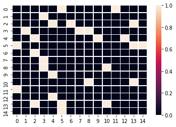

```
OptimizationStatus.OPTIMAL
```

```python
model = Model()

# variable binaire indicant si l'espion i peut contacter avec l'espion j
x = [[model.add_var(var_type=BINARY) for j in V] for i in V]

#ajout de la variable latente y
y = [[[model.add_var(var_type=BINARY) for j in V] for i in V] for k in V]

# ajout de l'objectif: minimiser la probabilité d'interception
model.objective = maximize(xsum(np.log(1-P[i][j])*x[i][j] for i in V for j in V))

#contrainte 1: on choisit 2*(n-1) et pas n-1 car le graphe est acyclique donc la solution sera symmétrique (xij = xji)
model += xsum(x[i][j] for i in V for j in V) == 2*(n-1)

#contrainte 2:
for (i,j) in product(V, V):
    for k in V:
        model += y[k][i][j] + y[k][j][i] == x[i][j]

#contrainte 3 :
for (i,j) in product(V, V):
    model += xsum(y[j][i][k] for k in V - {i,j}) + x[i][j] == 1

# optimisation
status = model.optimize()

# on vérifie si une solution à été trouvée, et on l'affiche le cas échéant
if model.num_solutions >0:
    out.write('Répartition trouvée avec distance totale: %s'
              % (model.objective_value))
#     X = [[x[i][j].x if j>i else 0 for j in V] for i in V]
    X = [[x[i][j].x for j in V] for i in V]
    edges = [[P[i][j]*x[i][j].x if j>i else 0 for j in V] for i in V]
    sns.heatmap(X, linewidths=.5)
    plt.show()
print(status)
```

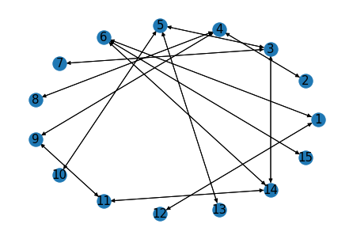

```python
import networkx as nx
G = nx.from_numpy_matrix(np.array(X), create_using=nx.MultiDiGraph())
pos = nx.circular_layout(G)
nx.draw_circular(G)
labels = {i : i + 1 for i in G.nodes()}
nx.draw_networkx_labels(G, pos, labels, font_size=15)
plt.show()
```

Afin de minimiser la probabilité d'interception, l'arbre recouvrant de poids minimal est donc celui ci.

```python
G.edges()
```

```
OutMultiEdgeDataView([(0, 5), (0, 11), (1, 3), (2, 4), (2, 6), (2, 13), (3, 1), (3, 7), (3, 8), (4, 2), (4, 9), (4, 12), (5, 0), (5, 13), (5, 14), (6, 2), (7, 3), (8, 3), (8, 10), (9, 4), (10, 8), (10, 13), (11, 0), (12, 4), (13, 2), (13, 5), (13, 10), (14, 5)])
```

```python
prob = 1
edges = np.array(edges)
for i in range(n):
    for j in range(n):
        if edges[i][j] > 0:
            prob *= 1-edges[i,j]
print("Probabilité d'interception: {} %".format(1-prob))
```

[output not shown]

## 2.3 Approvisionnement d'un chantier

```python
d = np.loadtxt('DonneesEnginsChantier.txt')
p_loc = 200
p_init = 800
p_fin = 1200
```

On peut facilement résoudre ce problème avec de la programmation linéaire en nombre entier, comme précédemment:

$x_t$ représente le nombre de machines en location durant la semaine t, $y_t$ représente le nombre de machines acheminées sur site au début de la semaine t (elles peuvent être utilisées dès la semaine t), et $z_t$ représente le nombre de machines rendues à la fin de la semaine t (elles peuvent donc être utilisées durant la semaine t). Soit V l'ensemble des semaines numérotées de 0 à n-1.

La première contrainte assure que la demande en machine est remplie.

La deuxième contrainte assure que toutes les machines soient rendues à la fin des N semaines, et la troisième assure la relation entre x, y et z

$min \sum_t x_t p_{loc} + y_t p^{init} + z_t p^{fin} \\ s.t.: \\ x_t \ge d_t \forall t \in V \\ \sum_{t \in V} y_t - z_t = 0 \\ \forall T \in [\![1, n-1]\!] \ \ \sum_{t=1}^T y_t - z_{t-1} = x_T \\ y_0 \ge d_0 \\ x_t, y_t, z_t \in \mathbb{N} \\ V = [\![0, n-1]\!] $

```python
n, V = len(d), set(range(len(d)))

model = Model()

# variable binaire indicant si l'espion i peut contacter avec l'espion j
x = [model.add_var(var_type=INTEGER) for t in V]

#ajout de la variable latente y
y = [model.add_var(var_type=INTEGER) for t in V]

#ajout de la variable latente y
z = [model.add_var(var_type=INTEGER) for t in V]

# ajout de l'objectif: minimiser la distance totale
model.objective = minimize(xsum(x[t]*p_loc+y[t]*p_init + z[t]*p_fin for t in V))

#contrainte 1:
for t in V:
    model += x[t] >= d[t]

model += xsum(y[t] - z[t] for t in V) == 0

model += y[0] >= d[0]

for T in V-{0}:
    model += xsum(y[t] - z[t-1] for t in range(1, T+1)) == x[T]

# optimisation
status = model.optimize()

# on vérifie si une solution à été trouvée, et on l'affiche le cas échéant
if model.num_solutions >0:
    print('Répartition trouvée avec coût total: %s'
              % (model.objective_value))
    X = [x[t].x for t in V]
    Y = [y[t].x for t in V]
    Z = [z[t].x for t in V]
    print("Nombre d'engins loués par semaine: ", X)
    print("Nombre d'engins apportés sur le chantier pour la première fois par semaine: ", Y)
    print("Nombre d'engins rendus par semaine: ", Z)
print(status)
```

```
Répartition trouvée avec coût total: 3383200.0
Nombre d'engins loués par semaine:  [36.0, 61.0, 84.0, 87.0, 121.0, 121.0, 121.0, 121.0, 121.0, 121.0, 121.0, 149.0, 149.0, 158.0, 158.0, 158.0, 158.0, 180.0, 170.0, 165.0, 158.0, 131.0, 131.0, 131.0, 131.0, 131.0, 131.0, 131.0, 131.0, 131.0, 131.0, 131.0, 131.0, 126.0, 126.0, 126.0, 126.0, 126.0, 1…
Nombre d'engins apportés sur le chantier pour la première fois par semaine:  [36.0, 61.0, 23.0, 3.0, 34.0, 0.0, 0.0, 0.0, 0.0, 0.0, 0.0, 28.0, 0.0, 9.0, 0.0, 0.0, 0.0, 22.0, 0.0, 0.0, 0.0, 0.0, 0.0, 0.0, 0.0, 0.0, 0.0, 0.0, 0.0, 0.0, 0.0, 0.0, 0.0, 0.0, 0.0, 0.0, 0.0, 0.0, 0.0, 0.0, 0.0, 0.0, 0.0, 0…
Nombre d'engins rendus par semaine:  [0.0, 0.0, 0.0, 0.0, 0.0, 0.0, 0.0, 0.0, 0.0, 0.0, 0.0, 0.0, 0.0, 0.0, 0.0, 0.0, 0.0, 10.0, 5.0, 7.0, 27.0, 0.0, 0.0, 0.0, 0.0, 0.0, 0.0, 0.0, 0.0, 0.0, 0.0, 0.0, 5.0, 0.0, 0.0, 0.0, 0.0, 0.0, 0.0, 0.0, 0.0, 0.0, 0.0, 0.0, 0.0, 0.0, 0.0, 0.0, 0.0, 0.0, 0.0, 0.0, …
OptimizationStatus.OPTIMAL
```

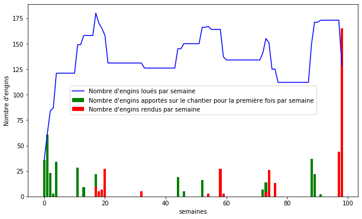

```python
S = [i for i in range(n)]
fig = plt.figure(figsize=(10,6))
plt.plot(S, X, label="Nombre d'engins loués par semaine", color='blue')
plt.bar(S, Y, label = "Nombre d'engins apportés sur le chantier pour la première fois par semaine", color='green')
plt.bar(S, Z, label = "Nombre d'engins rendus par semaine", color='red')
plt.xlabel('semaines')
plt.ylabel("Nombre d'engins")
plt.legend(loc='best')
plt.show()
```

## 3. Optimisation multi-objectif : dimensionnement d'une poutre

### Méthode gloutonne

La stratégie utilisée pour obtenir le front de Pareto est de récupérer l'enveloppe des points réalisables. L'ensemble des points réalisables est le suivant:

$$ \{ p(a,b), d(a,b) \ | \ \ 0.02 \leq a \leq 1, 0 \leq b \leq a-0.01 \} $$

Ensuite il s'agit, pour chaque valeur de deflexion $d(a,b)$, de récupérer le minimum des poids $p(a,b)$. Le tracé est effectué ci-dessous avec l'ensemble des points admissibles en vert et le front de Pareto en rouge.

```python
def poids(a, b):
    return a**2 - b**2

def deflexion(a, b):
    return (10**-4)/(10**-2 + a**4 - b**4)
```

```python
N = 1000
A = np.random.uniform(0.02,1,N)
B = np.array([np.random.uniform(0, a - 0.01) for a in A])
```

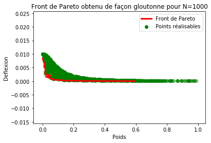

```python
plt.scatter(poids(A, B), deflexion(A, B), alpha=0.5, color="green", label="Points réalisables");
n = 20
deflex_log = np.logspace(-4,-1.97, n+1)
pareto_log = np.zeros(n)
for i in range(n):
    pareto_log[i] = np.min(poids(A,B)[np.where(np.logical_and(deflexion(A,B) > deflex_log[i], deflexion(A,B) <= deflex_log[i+1]))])
plt.plot(pareto_log, deflex_log[:-1] - 1e-4, color="red", label="Front de Pareto", linewidth=3);
plt.xlabel("Poids")
plt.ylabel("Deflexion")
plt.title("Front de Pareto obtenu de façon gloutonne pour N={}".format(N))
leg = plt.legend()
for lh in leg.legendHandles:
    lh.set_alpha(1)
```

```python
N = 100000
A = np.random.uniform(0.02,1,N)
B = np.array([np.random.uniform(0, a - 0.01) for a in A])
```

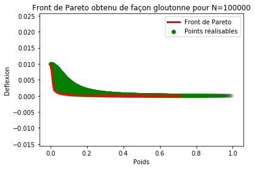

```python
plt.scatter(poids(A, B), deflexion(A, B), alpha=0.005, color="green", label="Points réalisables");
n = 60
deflex_log = np.logspace(-4,-1.97, n+1)
pareto_log = np.zeros(n)
for i in range(n):
    pareto_log[i] = np.min(poids(A,B)[np.where(np.logical_and(deflexion(A,B) > deflex_log[i], deflexion(A,B) <= deflex_log[i+1]))])
plt.plot(pareto_log, deflex_log[:-1] - 1e-4, color="red", label="Front de Pareto", linewidth=3);
plt.xlabel("Poids")
plt.ylabel("Deflexion")
plt.title("Front de Pareto obtenu de façon gloutonne pour N={}".format(N))
leg = plt.legend()
for lh in leg.legendHandles:
    lh.set_alpha(1)
```

La justesse du front de Pareto dépend de $N$, le nombre de couples $(a,b)$ générés. Pour obtenir un front de Pareto précis, il faut augmenter N. La métode est de complexité $O(N)$.

On remarque que le front n'est pas convexe. Il rebique pour des valeurs de déflexion proche de 0.010.

### Méthode plus sophistiquée

La recherche du front de Pareto peut être formulée à l'aide d'un problème d'optimisation mono-objectif paramétré par $\lambda$. En effet, le paramètre $\lambda$ gère le compromis entre poids et déflexion.

$$ \boxed{F(\lambda) = \min_{a, b \in X_{ad}} p(a,b) + \lambda d(a,b)} $$

```python
def objective(x,lambda_):
    """
    Returns the objective function p(a,b) + l*d(a,b)
    """
    a,b = x
    return poids(a,b) + lambda_*deflexion(a,b)

def constraint1(x):
    """
    b <= a-0.01
    """
    a,b = x
    return -(b-a+0.01)
```

```python
np.random.seed(2)
constraints = [
    {"type": "ineq", "fun": constraint1},
]
bounds = [(0.02, 1),(0, 0.99)]
a0 = np.random.uniform(low=0.02, high=1)
b0 = np.random.uniform(low=0, high=a0-0.01)
x0 = np.array([a0, b0])
lambdas = np.logspace(0,4,100)
solutions = [minimize(partial(objective, lambda_=lambda_), x0, constraints=constraints, bounds=bounds) for lambda_ in lambdas]
```

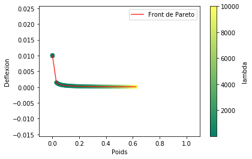

```python
X = np.array([sol["x"] for sol in solutions if sol["success"]])
plt.scatter(poids(X[:,0], X[:,1]), deflexion(X[:,0], X[:,1]), c=lambdas, cmap=plt.get_cmap("summer"));
plt.plot(poids(X[:,0], X[:,1]), deflexion(X[:,0], X[:,1]), color="red", alpha=0.8, label="Front de Pareto");
plt.legend();
plt.xlabel("Poids")
plt.ylabel("Deflexion")
eps = 0.1
plt.xlim(0-eps,1+eps);
plt.colorbar(label="lambda");
```

Puisque le front n'est pas entièrement convexe, il y a un saut dans les solutions du problème lorque le poids devient petit. On retrouve cependant le même front qu'avec la méthode gloutonne. L'avantage ici est que les solutions du front de Pareto sont exactes puisqu'il s'agit de la résolution de problèmes d'optimisation. L'inconvéniant est que cette méthode plus sophistiquée ne trouve qu'une enveloppe convexe du front et non le front lui-même. Cette méthode est par contre plus rapide car nécessite seulement la résolution de quelques problèmes d'optimisation, alors que la méthode gloutonne requiert un très grand nombre de points N et une complexité en $O(N)$.